# Data Analysis_Lucid

Alice Pao

2022-10-02

```r
library(tidyverse)
library(pander)

sub <- read_csv("https://grnhse-ghr-prod-s4.s3.amazonaws.com/generic_attachments/attachments/414/337/100/original/subscriptions.csv?X-Amz-Algorithm=AWS4-HMAC-SHA256&X-Amz-Credential=AKIAVQGOLGY37ZOEJKP2%2F20220930%2Fus-east-1%2Fs3%2Faws4_request&X-Amz-Date=20220930T181018Z&X-Amz-Expires=604800&X-Amz-SignedHeaders=host&X-Amz-Signature=c843fdb92f132e848e47012e9a8cf25b51f9c97b1ab534034e7696adab03e9d8")
visit <- read_csv("https://grnhse-ghr-prod-s4.s3.amazonaws.com/generic_attachments/attachments/414/337/000/original/visits.csv?X-Amz-Algorithm=AWS4-HMAC-SHA256&X-Amz-Credential=AKIAVQGOLGY37ZOEJKP2%2F20220930%2Fus-east-1%2Fs3%2Faws4_request&X-Amz-Date=20220930T181018Z&X-Amz-Expires=604800&X-Amz-SignedHeaders=host&X-Amz-Signature=4a1772331990a3563a294df983e4a2d3fa46eb92044324888be3d8a4e544f370")

join_dat <- sub %>%
  left_join(visit, by = "account_id")
```

## Q1

1. How much revenue did each region generate within the time frame covered by the data sets?

```r
sub %>%
  left_join(visit, by = "account_id") %>%
  group_by(region) %>%
  drop_na() %>%
  summarise(region_rev = sum(revenue)) %>%
  arrange(desc(region_rev)) %>%
  pander()
```

| region | region_rev |
| --- | --- |
| Latin America | 1083621 |
| Asia | 787801 |
| US/Canada | 745267 |
| Europe, Middle East, & Africa (Non-English) | 715693 |
| Other English-Speaking Countries | 632821 |

## Q2

Which channel had the highest revenue per visit? What was its revenue per visit?

> Display has the highest revenue per vist. Its revenue per visit is $917.

```r
join_dat %>%
  group_by(channel) %>%
  mutate(channel_total_visit = n()) %>%
  drop_na(revenue) %>%
  mutate(visit_rev = sum(revenue),
         rev_per_visit = visit_rev/channel_total_visit) %>%
  slice_max(rev_per_visit, n =1) %>%
  select(channel, rev_per_visit)
```

```
## # A tibble: 8,180 × 2
## # Groups:   channel [7]
##    channel rev_per_visit
##    <chr>           <dbl>
##  1 display          917.
##  2 display          917.
##  3 display          917.
##  4 display          917.
##  5 display          917.
##  6 display          917.
##  7 display          917.
##  8 display          917.
##  9 display          917.
## 10 display          917.
## # … with 8,170 more rows
```

## Q3

Which landing page had the highest overall conversion rate (% of visitors that go on to become paying subscribers)? What was its conversion rate?

> Landing page: H, conversion rate is 65.7%

```r
join_dat %>%
  group_by(landing_page) %>%
  mutate(total_visit = n()) %>%
  drop_na(subscription_start_date) %>%
  mutate(vis_to_sub_num = n(),
         conversion_rate = vis_to_sub_num / total_visit *100) %>%
  select(region, landing_page, conversion_rate) %>%
  arrange(desc(conversion_rate))
```

```
## # A tibble: 8,180 × 3
## # Groups:   landing_page [10]
##    region    landing_page conversion_rate
##    <chr>     <chr>                  <dbl>
##  1 US/Canada H                       65.7
##  2 US/Canada H                       65.7
##  3 US/Canada H                       65.7
##  4 US/Canada H                       65.7
##  5 US/Canada H                       65.7
##  6 US/Canada H                       65.7
##  7 US/Canada H                       65.7
##  8 US/Canada H                       65.7
##  9 US/Canada H                       65.7
## 10 US/Canada H                       65.7
## # … with 8,170 more rows
```

## Q4

Did any regions have a different top converting landing page (as compared to the previous answer)? If so, please list hem along with their top landing page and its conversion rate.

> Asia: H, 69.49%; Europe, Middle East, Africa: J, 64.77%; Latin America: E, 69.26%; Other English Speaking: I, 65.51%; US, Canada: H, 68.86%

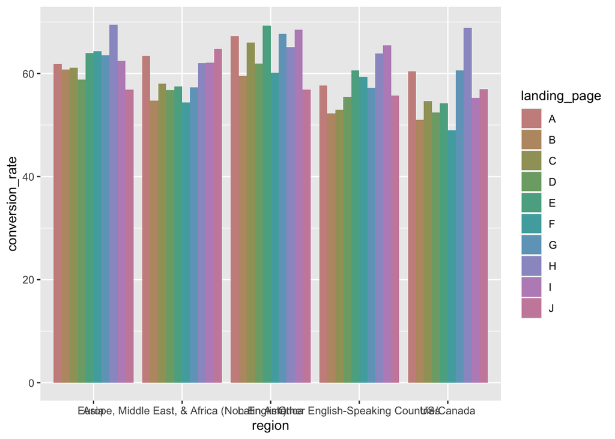

```r
# join_dat %>%
#   group_by(region) %>%
#   mutate(region_total_visit = n()) %>%
#   drop_na(subscription_start_date) %>%
#   group_by(landing_page) %>%
#   mutate(vis_to_sub_num = n(),
#          conversion_rate = vis_to_sub_num / region_total_visit * 100) %>%
#   View()
#   select(region, landing_page, conversion_rate) %>%
#   arrange(desc(conversion_rate)) %>%
#   ggplot(aes(x = region, y = conversion_rate, fill = landing_page))+
#   geom_col(position = "dodge")

join_dat %>%
  group_by(region, landing_page) %>%
  mutate(total_visit = n()) %>%
  drop_na(subscription_start_date) %>%
  mutate(vis_to_sub_num = n(),
         conversion_rate = vis_to_sub_num / total_visit * 100) %>%
  select(region, landing_page, conversion_rate) %>%
  arrange(desc(conversion_rate)) %>%
  ggplot(aes(x = region, y = conversion_rate, fill = landing_page))+
  geom_col(position = "dodge")+
  scale_fill_hue(c=40)
```

## Q5

Which region had the highest direct subscription rate (% of visitors that start a subscription directly without doing a trial)? What was its direct subscription rate?

```r
join_dat %>%
  drop_na(trial_start_date, subscription_start_date) %>%
  mutate(total_dir_sub = n()) %>%
  group_by(region) %>%
  summarise(dir_vis_sub_num = n(),
            dir_sub_rate = dir_vis_sub_num / total_dir_sub * 100) %>%
  arrange(desc(dir_sub_rate))
```

```
## # A tibble: 3,992 × 3
## # Groups:   region [5]
##    region        dir_vis_sub_num dir_sub_rate
##    <chr>                   <int>        <dbl>
##  1 Latin America            1018         25.5
##  2 Latin America            1018         25.5
##  3 Latin America            1018         25.5
##  4 Latin America            1018         25.5
##  5 Latin America            1018         25.5
##  6 Latin America            1018         25.5
##  7 Latin America            1018         25.5
##  8 Latin America            1018         25.5
##  9 Latin America            1018         25.5
## 10 Latin America            1018         25.5
## # … with 3,982 more rows
```

## Q6

Which region had the highest trial start rate (% of visitors that start a trial, regardless of whether those users ultimately cancel or become paying subscribers)? What was its trial start rate?

> Latin America, 23.3%

```r
join_dat %>%
  drop_na(trial_start_date) %>%
  mutate(total_trial_num = n()) %>%
  group_by(region) %>%
  mutate(region_trial_num = n())%>%
  summarise(trial_start_rate = region_trial_num / total_trial_num *100) %>%
  arrange(desc(trial_start_rate))
```

```
## # A tibble: 9,424 × 2
## # Groups:   region [5]
##    region        trial_start_rate
##    <chr>                    <dbl>
##  1 Latin America             23.3
##  2 Latin America             23.3
##  3 Latin America             23.3
##  4 Latin America             23.3
##  5 Latin America             23.3
##  6 Latin America             23.3
##  7 Latin America             23.3
##  8 Latin America             23.3
##  9 Latin America             23.3
## 10 Latin America             23.3
## # … with 9,414 more rows
```

## Q7

Which region had the highest trial conversion rate (% of trials that start a subscription)? What was its trial conversion rate?

> Latin American, 25.5%

```r
# join_dat %>%
#   drop_na(trial_start_date) %>%
#   mutate(total_trial_num = n()) %>%
#   drop_na()
join_dat %>%
  drop_na(trial_start_date, subscription_start_date) %>%
  mutate(total_num_tri_to_sub = n()) %>%
  group_by(region) %>%
  summarise(region_num_tri_to_sub = n(),
            trial_conversion_rate = region_num_tri_to_sub / total_num_tri_to_sub *100) %>% arrange(desc(trial_conversion_rate))
```

```
## # A tibble: 3,992 × 3
## # Groups:   region [5]
##    region        region_num_tri_to_sub trial_conversion_rate
##    <chr>                         <int>                 <dbl>
##  1 Latin America                  1018                  25.5
##  2 Latin America                  1018                  25.5
##  3 Latin America                  1018                  25.5
##  4 Latin America                  1018                  25.5
##  5 Latin America                  1018                  25.5
##  6 Latin America                  1018                  25.5
##  7 Latin America                  1018                  25.5
##  8 Latin America                  1018                  25.5
##  9 Latin America                  1018                  25.5
## 10 Latin America                  1018                  25.5
## # … with 3,982 more rows
```

## Q8

Suppose that the company has a goal to increase revenue from the US/Canada region by 20% over the next year. Provide at least 4 potential strategies we could employ to help us reach our goal (no supporting data analysis required—just ideas).

1. Increase budget for channel that has the highest revenue per visit
2. Analyze the demographic of current subscribers to find the target audience and design a marketing campaign based on the TA
3. Revive old cancelled subscribers
4. Find out why people don’t keep their subscriptions after trial sub and optimize the products so we can increase the trial subscription retention rate